# Predict Buy Now Pay Later service adoption and delinquency using SHED data

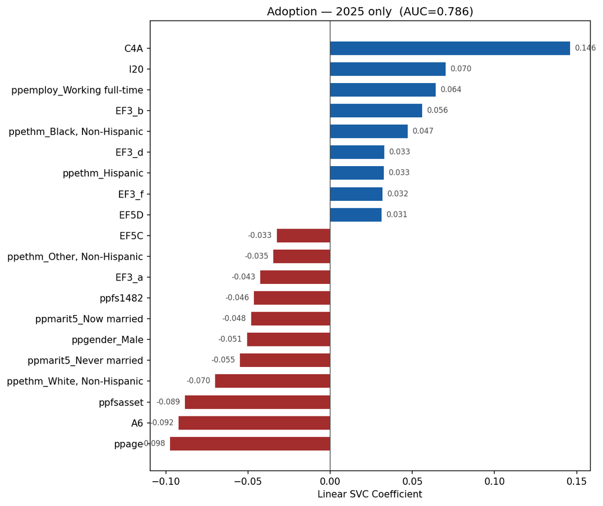

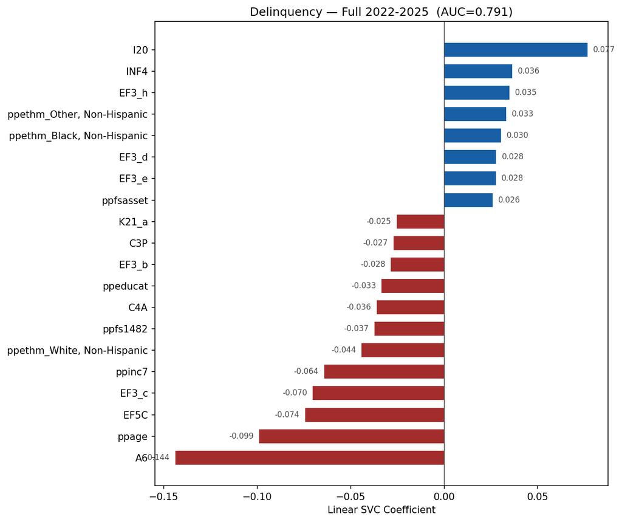

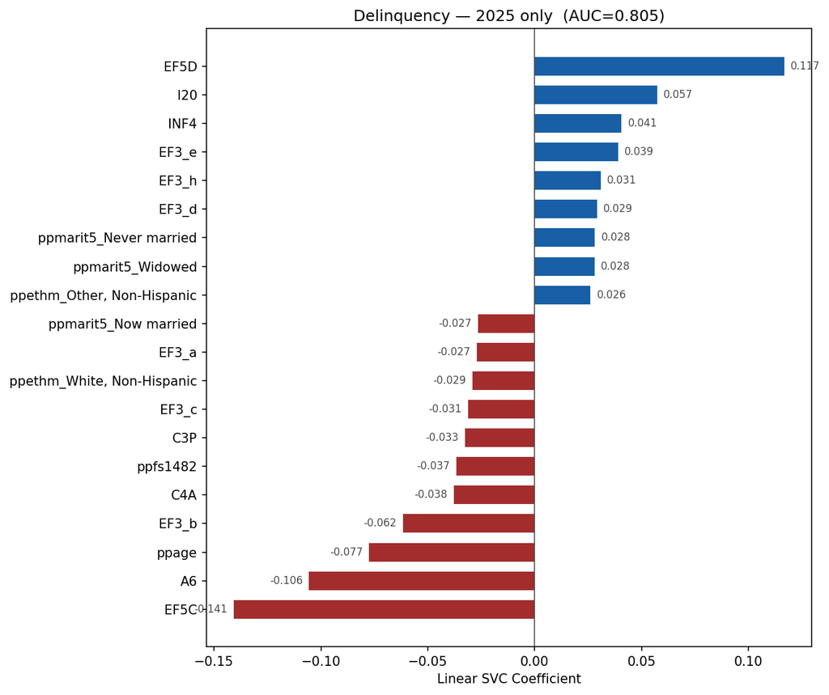

Blue = increases BNPL probability | Red = decreases BNPL probability | Coefficients on standardised features

### Non-Linear SVC

Kernel SVC with RBF was tested as a non-linear alternative, searching over C ∈ {0.1, 1, 10} and gamma ∈ {scale, 0.01, 0.1} via 5-fold cross-validation. Despite achieving reasonable AUC scores (0.68–0.83), the model collapsed recall on the minority class to near zero for adoption — predicting almost all observations as “No” — making it unsuitable for this task. This is a known limitation of kernel SVC under severe class imbalance: the radial basis function optimizes a smooth margin that gets dominated by the majority class geometry, and class_weight=‘balanced’ is less effective at correcting this than in linear models. Combined with O(n²) training complexity making it impractical at N=48,294, kernel SVC was excluded from the final model comparison.

### XGBoost

XGBoost was selected as the final model to capture non-linear interactions and threshold effects that linear models cannot. Unlike LASSO and LinearSVC, XGBoost handles missing values natively — allowing the split-ballot columns (`L0C`, `A1_a/b/c`, `X12_a–g`, `EF5D`) to be included in the full feature set without imputation. No feature scaling was applied. Class imbalance was handled via `scale_pos_weight` (the negative-to-positive ratio: 6.5 for adoption, 4.0 for delinquency). Hyperparameter tuning searched over `max_depth` ∈ {3, 5}, `learning_rate` ∈ {0.05, 0.1}, and `n_estimators` ∈ {100, 200} via 5-fold stratified cross-validation optimising AUC-ROC.

```python
# XGBoost model

scale_pos_weight = (y==0).sum() / (y==1).sum()  # ~6.5 adoption, ~4.0 delinquency

XGBClassifier(
    scale_pos_weight=scale_pos_weight,
    eval_metric='auc',
    random_state=42
)
```

**Results**

|  | Adoption Full | Adoption 2025 | Delinquency Full | Delinquency 2025 |
| --- | --- | --- | --- | --- |
| AUC | 0.812 | 0.831 | 0.839 | 0.868 |
| Recall “Yes” | — | — | 0.249 | 0.839 |

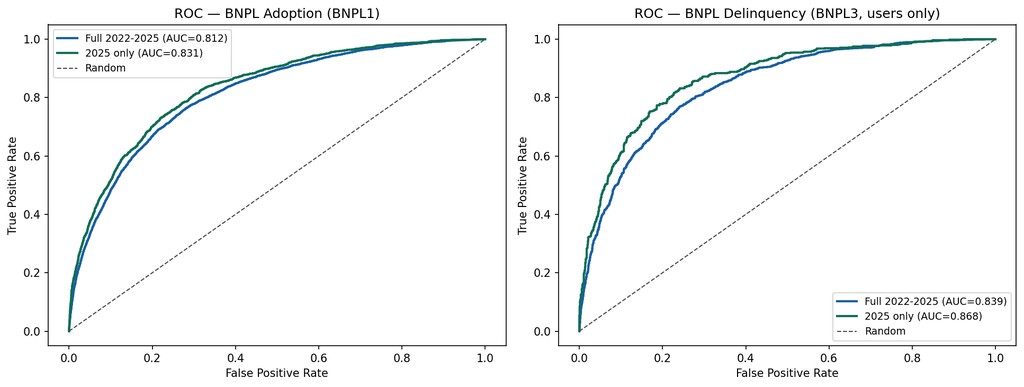

**SHAP Analysis**

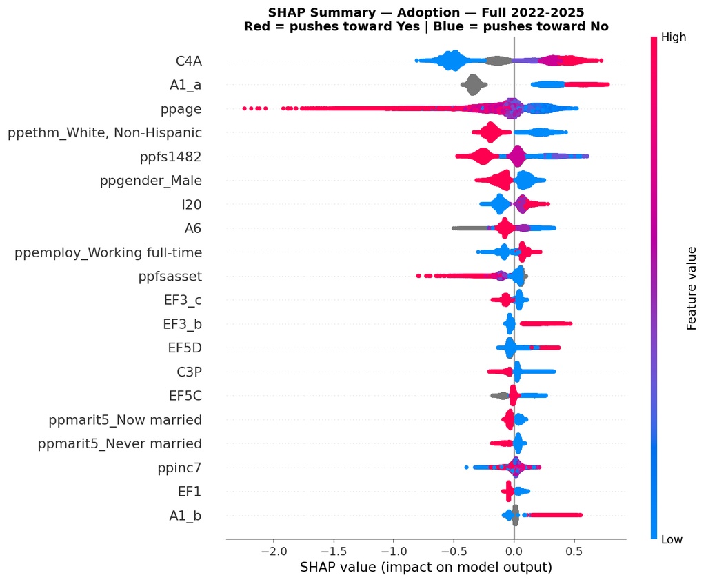

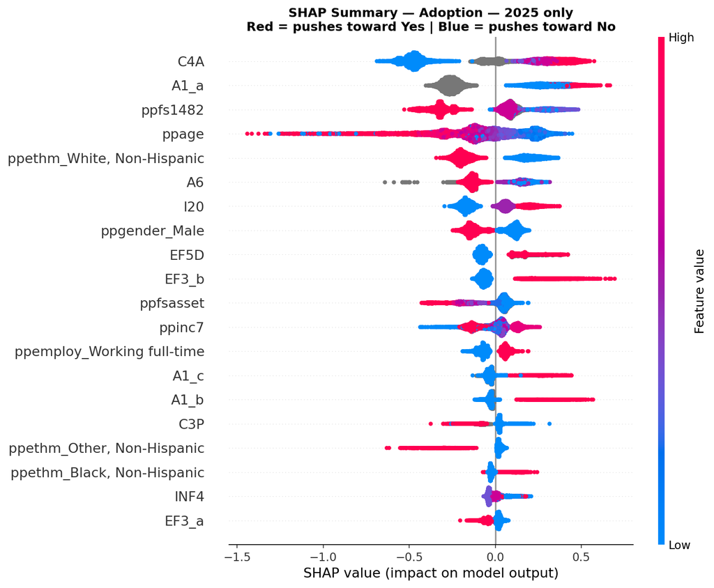